# Objectif

L'objectif de notre étude est de créer une application qui, lorsque l'on entre un produit alimentaire d'origine étrangère, nous suggère un produit équivalent d'origine française.

Ce premier notebook contiendra l'analyse exploratoire ainsi que le nettoyage des données. Le résultat obtenu ici sera par la suite utilisé pour toutes les étapes de machine learning dans un prochain notebook.

# Chargement des Packages

```python
%matplotlib inline

import numpy as np
import matplotlib.pyplot as plt
import pandas as pd
import seaborn as sns
import requests
import os
import missingno as msno
from scipy import stats

pd.options.mode.chained_assignment = None
```

# Chargement du dataset

Création d'un répertoire "data" et téléchargement des données si ce n'est pas déjà fait :

```python
file_url = "https://static.openfoodfacts.org/data/en.openfoodfacts.org.products.csv"
if not os.path.exists('data'):
    os.makedirs('data')

if not os.path.exists("./data/en.openfoodfacts.org.products.csv"):
    request.urlretrieve (file_url, "./data/en.openfoodfacts.org.products.csv")

offdata = pd.read_csv("./data/en.openfoodfacts.org.products.csv", sep = "\t")
```

# Analyse Exploratoire

## Dimensions

Regardons les dimensions du dataset

```python
print(offdata.shape)
print("Notre dataset contient {} observations et {} variables".format(offdata.shape[0],
                                                                      offdata.shape[1]))
```

```
(1555491, 183)
Notre dataset contient 1555491 observations et 183 variables
```

## Variables

Regardons quelles sont les variables disponibles :

```python
offdata.columns
```

```
Index(['code', 'url', 'creator', 'created_t', 'created_datetime',
       'last_modified_t', 'last_modified_datetime', 'product_name',
       'generic_name', 'quantity',
       ...
       'carbon-footprint-from-meat-or-fish_100g', 'nutrition-score-fr_100g',
       'nutrition-score-uk_100g', 'glycemic-index_100g', 'water-hardness_100g',
       'choline_100g', 'phylloquinone_100g', 'beta-glucan_100g',
       'inositol_100g', 'carnitine_100g'],
      dtype='object', length=183)
```

## Valeurs manquantes

Avant d'aller plus loin dans l'exploration, regardons la structure de notre dataset en termes de valeurs manquantes. Pour cela, le package *missingno* nous propose plusieurs outils de visualisation, dont la fonction *msno.matrix()* qui nous montre la lacunarité de chaque colonne ; De plus, la dernière colonne résume la lacunarité de chaque ligne.

Compte tenu de la grande taille de notre dataset, nous ferons cette étude sur un échantillon de 1000 observations :

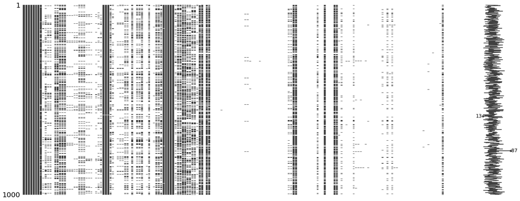

```python
msno.matrix(offdata.sample(1000))
```

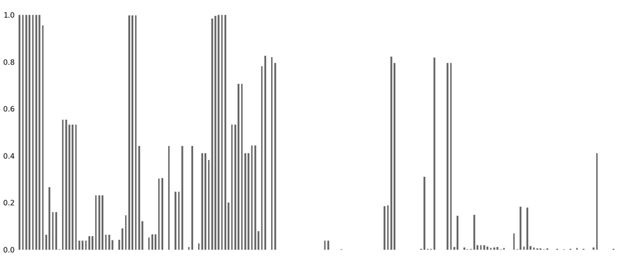

```python
msno.bar(offdata.sample(1000))
```

On a un dataset qui, dans l'ensemble, est très lacunaire. Seules quelques variables semblent facilement exploitables.

## Pays

On cherche les variables contenant des informations relatives aux pays d'origine des produits.

On sera plusieurs fois amenés à rechercher des colonnes durant notre étude ; par conséquent, pour alléger le code, on automatisera ce procédé par la fonction *find_cols()* ci-dessous :

```python
def find_cols(df, txt):
    return(df.columns[df.columns.str.contains(txt, case = False)].tolist())
```

Retournons à notre recherche :

```python
find_cols(offdata, "origin")
```

```
['origins', 'origins_tags', 'origins_en']
```

On cherchera dans cette étude à réaliser un *proof of concept* sur deux pays, la France et l'Allemagne. On regarde selon quelle colonne on fera le tri :

```python
for feature in find_cols(offdata, "origin"):
    print(feature, len(offdata[feature][offdata[feature].str.contains("france", case = False, na = False)]))
```

```
origins 22405
origins_tags 22747
origins_en 22747
```

```python
for feature in find_cols(offdata, "origin"):
    print(feature, len(offdata[feature][offdata[feature].str.contains("german", case = False, na = False)]))
```

```
origins 293
origins_tags 1844
origins_en 1844
```

```python
offdata2 = offdata[offdata["origins_en"].str.contains("france|german", case = False, na = False)]
```

# Selection de variables

Maintenant que ce premier filtre est fait, nous regarderons quelles seront les variables que nous retiendrons pour notre étude.

Le dataset obtenu reste, tout comme celui d'origine, assez lacunaire dans l'ensemble :

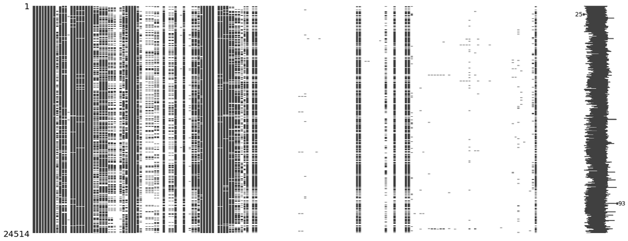

```python
msno.matrix(offdata2)
```

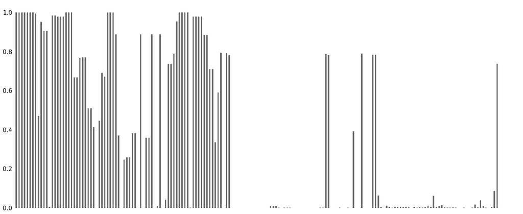

```python
msno.bar(offdata2)
```

### Objectif de la sélection

Pour suggérer un produit français similaire a celui que l'on a, notre application passera par un clustering des produits. Lorsqu'on lui montre un produit allemand, l'application nous proposera alors un produit français contenu dans le même cluster.

Pour réaliser cette clusterisation, nous choisiront les variables contenant des informations nutritives du produit ainsi que sa catégorie. En effet, les informations nutritives seules peuvent être insuffisantes. Supposons que, par exemple, le riz et les pommes de terres aient des caractéristiques similaires, ces deux produits différents risquent d'être dans le même cluster. La variable "catégorie" interviendra alors pour les différencier.

Les variables qui nous intéresseront pour la classification sont donc :

- La variables relatives à la catégorie du produit
- Les informations nutritives, qui se remarquent par la précence des caractères "100g" dans le nom des variables
- Les nutriscore et nutrigrade, qui contiennent également des informations nutritives

Lorsque l'on recherche les variables répondant à ce critère, on en trouvent un grand nombre :

```python
len(find_cols(offdata2, "100g|categories|grade"))
```

```
115
```

De plus, même en ne sélectionnant que ces variables, on obtient un dataset très lacunaire :

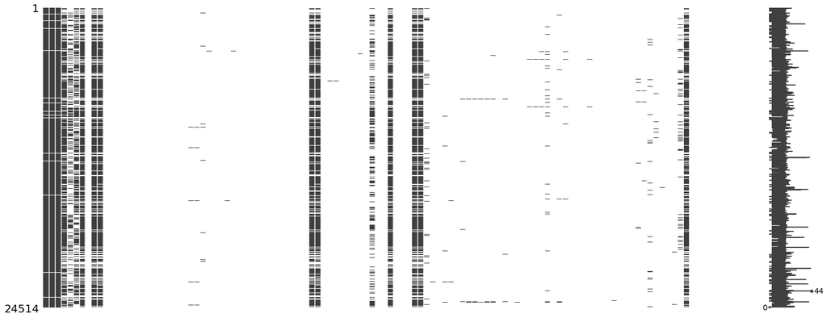

```python
msno.matrix(offdata2.loc[:, find_cols(offdata2, "100g|categories|grade")], filter = "top", p = 0)
```

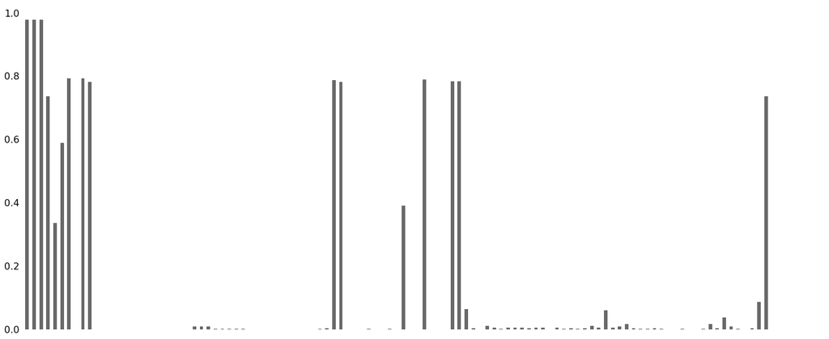

```python
msno.bar(offdata2.loc[:, find_cols(offdata2, "100g|categories|grade")], filter = "top", p = 0)
```

On prend alors le risque de choisir trop de variables qui contiennent peu ou pas d'informations. Un trop grand nombre de variables peut affaiblir la performance de notre modèle de clustering. Pour filtrer cela, on ne garde que les variables contenant moins de 50% de valeurs manquantes, et on regarde celles que l'on obtient :

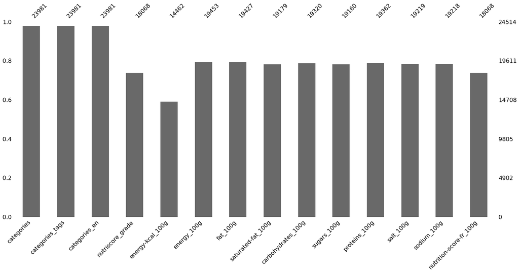

```python
msno.bar(offdata2.loc[:, find_cols(offdata2, "100g|categories|grade")], labels = True, filter = "top", p = 0.5)
```

Les variables retenues ont, dans l'ensemble, un faible nombre de valeurs manquantes (moins de 20% en général). De plus, plusieurs groupes de variables semblent avoir le même nombre de valeurs manquantes. On regardera alors si leurs lacunes sont coréllées, c'est-à-dire si les valeurs manquantes sont situées aux mêmes endroits :

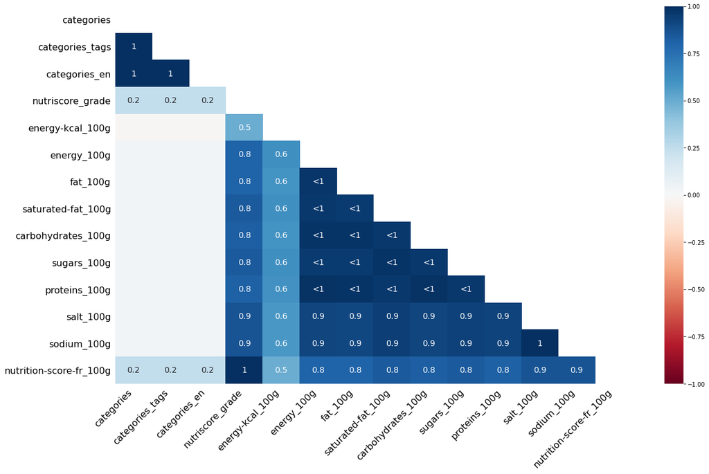

```python
msno.heatmap(offdata2.loc[:, find_cols(offdata2, "100g|categories|grade")], labels = True, filter = "top", p = 0.5)
```

On remarque deux groupes de corrélation :

- Les variables concernant la catégorie du produit ont leurs lacunes corrélées. Parmis celles-ci, nous garderons la variable *categories_en"
- Les variables contenant les informations nutritives ont leurs lacunes corrélées.

Ceci signifie que le nettoyage des valeurs manquantes sera assez rapide car nettoyer pour une variable signifie faire ce travail pour plusieurs colonnes à la fois.

Nous garderons donc toutes ces variables pour l'instant, ainsi que plusieurs variables d'identification, à savoir le nom du produit, son fabriquant, et son origine :

```python
selected_features = ["product_name", "brands", "categories_en", "origins_en",
                     "energy-kcal_100g", "energy_100g", "fat_100g", "saturated-fat_100g", "carbohydrates_100g",
                     "sugars_100g", "proteins_100g", "salt_100g", "sodium_100g", "nutrition-score-fr_100g", "nutriscore_grade"]
```

```python
offdata3 = offdata2.loc[:, selected_features]
```

On regarde une fois encore la lacunarité de notre dataset :

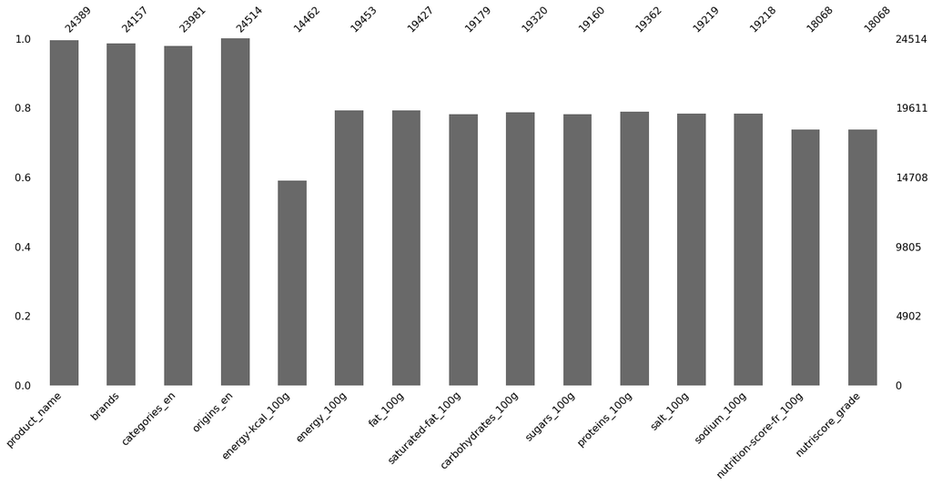

```python
msno.bar(offdata3)
```

On obtient une data frame avec assez peu de valeurs manquantes, même après ajout des variables d'identification, à l'exception de *energy-kcal_100g"* qui contient 40% de valeurs manquantes.

On remarque qu'il y a une forte possibilité qu'il y ait des redondances au niveau des variables conservées, telles que les deux variables qui concernent l'energie, voire même les informations nutritives entre elles.

Pour éliminer ces éventuelles redondances, on étudiera les corrélations entre nos variables.

## Corrélation

Comparons les variables entre elles en termes de corrélation :

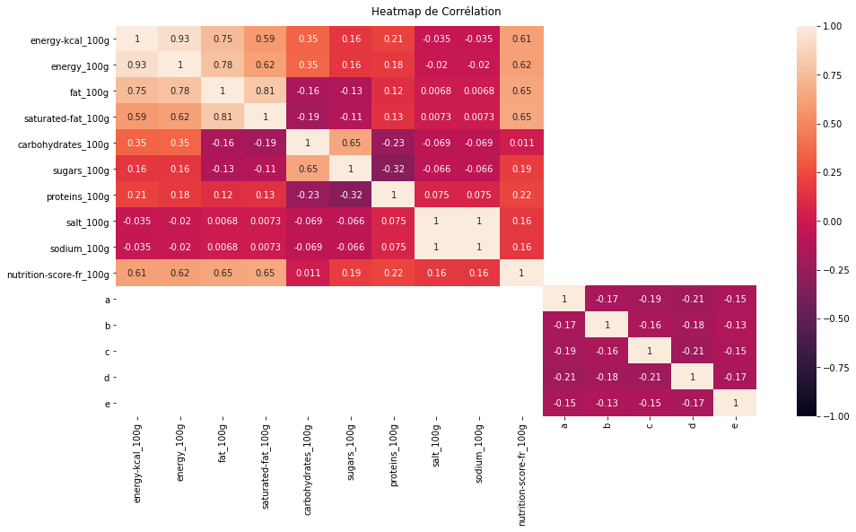

```python
plt.figure(figsize = (16, 8))
corrheatmap = sns.heatmap(pd.concat([offdata3.drop(columns = "nutriscore_grade"),
                                    pd.get_dummies(offdata3["nutriscore_grade"])]).corr(),
                          vmin = -1, vmax = 1, annot = True)
corrheatmap.set_title("Heatmap de Corrélation", fontdict = {"fontsize" : 12}, pad = 12)
```

On observe les corrélations suivantes :

- Energy-kcal et energy sont corrélées à 93%. On supprimera alors energy-kcal, qui contient plus de valeurs manquantes
- Salt et sodium sont corrélées à 100%. On supprimera sodium
- Fat et saturated-fat sont corrélées à 81%, mais les deux notions, bien que liées, sont différentes. On conservera les deux.

La corrélation de la variable catégorique nutriscore_grade avec les autres, en particulier nutrition-score-fr_100g n'est pas prise en charge par la heatmap, même après encodage.

Intuitivement, il est fortement probable que les deux variables "score" soient fortement corrélées, on cherchera donc à étudier cela au travers d'autres outils.

Pour cela, on effectue une ANOVA :

```python
F, p = stats.f_oneway(offdata3[offdata3.nutriscore_grade == "a"]["nutrition-score-fr_100g"],
                      offdata3[offdata3.nutriscore_grade == "b"]["nutrition-score-fr_100g"],
                      offdata3[offdata3.nutriscore_grade == "c"]["nutrition-score-fr_100g"],
                      offdata3[offdata3.nutriscore_grade == "d"]["nutrition-score-fr_100g"],
                      offdata3[offdata3.nutriscore_grade == "e"]["nutrition-score-fr_100g"],
                     )
F, p
```

```
(61340.91681902283, 0.0)
```

L'ANOVA donne une valeur F extrêment élevée ainsi qu'une p-value proche de 0. Il y a donc une forte corrélation entre le *nutriscore_grade* et le *nutrition-score-fr_100g* ; on peut par conséquent en supprimer une sans perdre d'information.

La variable *nutriscore_grade* étant catégorique, elle devra être encodée, ce qui multipliera le nombre de variables injectées au modèle de clustering et affaiblira sa performance. On préfèrera donc garder la variable numérique *nutrition-score-fr_100g*.

```python
offdata3.drop(columns = ["energy-kcal_100g", "sodium_100g", "nutriscore_grade"], inplace = True)
```

# Nettoyage des données

## Structure de la variable *Origins_en*

Lors de notre premier filtre, nous n'avons gardé que les produits allemands et français grâce à un tri sur la variable *origins_en*.

Cependant, cette variable n'a pas une structure idéale uniquement composée des valeurs "france" et "germany" :

```python
offdata3["origins_en"].unique().tolist()[1:10]
```

```
['Germany',
 'France,Fougerolles',
 'France,fr:ardeche',
 'fr:france-et-sans-gluten',
 'Denmark,Germany,Italy',
 'Made-in-germany',
 'Allemagne-germany',
 'France,fr:cergy-pontoise',
 'Germany,Netherlands']
```

Au contraire, nous avons un grand nombre de valeurs différentes :

```python
len(offdata3["origins_en"].unique())
```

```
2341
```

Nous allons devoir transformer ses valeurs pour obtenir une variable catégorique ne contenant que deux valeurs, "France" et "Germany"

On considèrera qu'un pays ayant plusieurs origines dont la France pourra être suggéré par l'application.

Par conséquent, tout produit contenant "France" dans ses origines sera considéré comme Français.

Tous les autres produits seront considérés comme étrangers.

On commence alors par créer un masque renvoyant le booléen **True** si le mot "france" apparaît, et **False** sinon :

```python
masque_france = offdata3["origins_en"].str.contains("france", case = False, na = False)
```

Puis on remplace les valeurs de la colonne "origins" par "France" ou "Foreign" selon le filtrage du masque :

```python
offdata3.loc[masque_france, "origins_en"] = "France"
```

```python
offdata3.loc[~masque_france, "origins_en"] = "Foreign"
```

```python
offdata3["origins_en"].unique().tolist()
```

```
['France', 'Foreign']
```

On obtient bien une colonne contenant uniquement ces deux valeurs.

## Nettoyage des valeurs manquantes

Le dataset est suffisamment grand et sa lacunarité suffisamment faible pour que l'on supprime les valeurs manquantes sans trop grande perte de données :

```python
print("Notre dataset contient {} observations et {} variables".format(offdata3.shape[0],
                                                                      offdata3.shape[1]))
```

```
Notre dataset contient 24514 observations et 12 variables
```

De plus, compléter les valeurs manquantes par leurs moyennes ou par des algorithmes de similarité ou proximité tels que le KNN peut biaiser notre futur modèle de classification, dans la mesure où l'on cherchera justement à classifier par similarité ou proximité au travers d'un clustering.

Avant de supprimer, regardons à nouveau la répartition des valeurs manquantes :

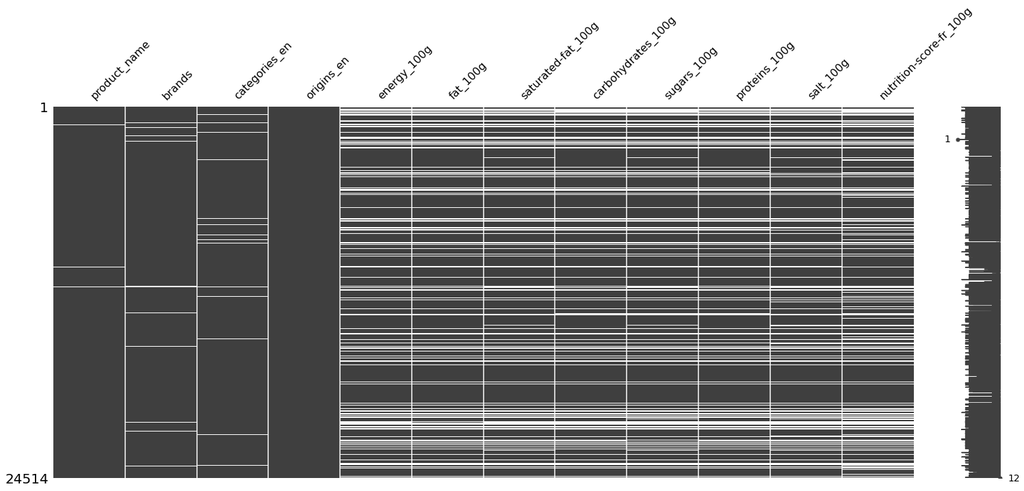

```python
msno.matrix(offdata3)
```

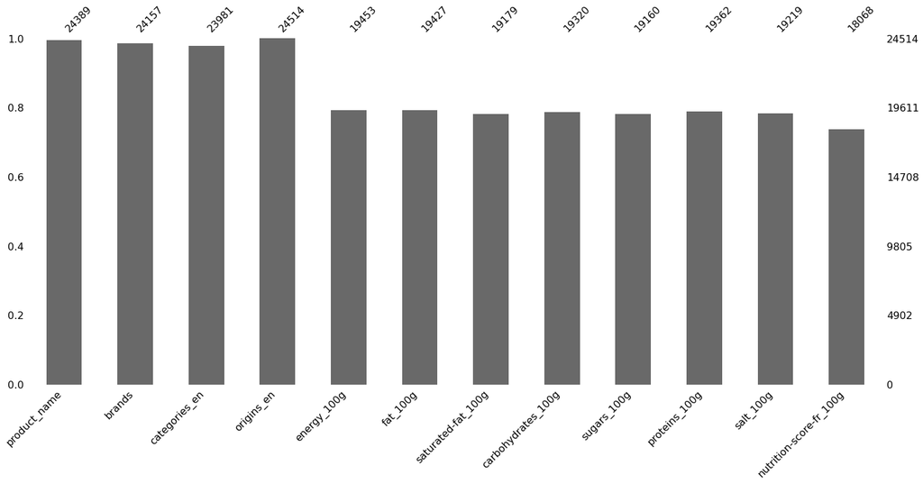

```python
msno.bar(offdata3)
```

Supprimons-les à présent de notre dataset :

```python
offdata4 = offdata3.dropna()
```

```python
print("Notre dataset contient {} observations et {} variables".format(offdata4.shape[0],
                                                                      offdata4.shape[1]))
```

```
Notre dataset contient 17668 observations et 12 variables
```

## Détection des doublons et redondances

Sur les 17668 lignes restantes, il est possibles que certaines apparaîssent plusieurs fois à l'identique. Pour fiabiliser notre futur modèle, il est nécessaire de les éliminer du dataset.

Regardons combien nous en avons :

```python
offdata4.duplicated().sum()
```

```
125
```

Nous avons 125 redondances. Compte tenu de la taille du dataset, c'est relativement peu (environ 7‰).

On les retire du dataset :

```python
offdata4.drop_duplicates(inplace = True)
```

```python
print("Notre dataset contient {} observations et {} variables".format(offdata4.shape[0],
                                                                      offdata4.shape[1]))
```

```
Notre dataset contient 17543 observations et 12 variables
```

## Détection des valeurs aberrantes (outliers)

Reprenons à nouveau la structure de notre dataset. Sur nos 12 variables, 3 sont des variables d'identification (*product_name*, *brands*, et *origins_en*), 1 est une variable catégorique (*categories_en*) et 8 sont des variables numériques.

Nos variables numériques ont une particularité, qui est que les informations nutritionnelles sur 100g ont une valeur comprise, naturellement, entre 0 et 100 (hormis l'energie qui fonctionne différemment).

Le nutriscore fonctionne, lui, sur une échelle de -15 (favorable sur le plan nutritionnel) à 40 (défavorable) selon [le rapport Hercberg de 2013](https://solidarites-sante.gouv.fr/IMG/pdf/rapport_Hercberg_15_11_2013.pdf), résumé dans [ce logigramme](https://quoidansmonassiette.fr/wp-content/uploads/2018/05/Infographie-calcul-nutriscore-logo-nutritionnel-score-corrig%C3%A9-668x1536.jpg).

Par conséquent, une valeur négative ou une valeur supérieure à 100 est aberrante et devra être traitée.

De plus, on cherchera également à étudier les valeurs anormalement élevées. Par exemple, un aliment contenant 90g de sel pour 100g est suspect ; seul du sel peut contenir une telle concentration.

Commençons par regarder les distributions de nos valeurs numériques :

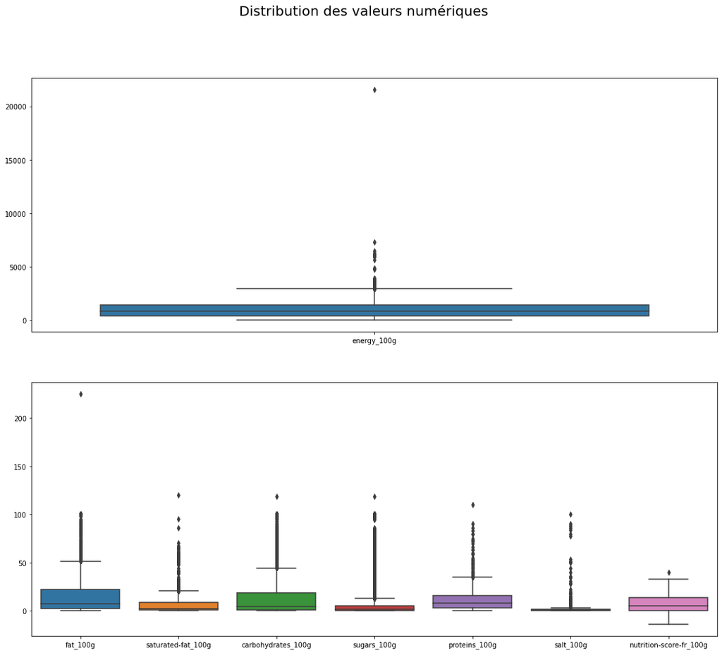

```python
fig, axes = plt.subplots(2, 1, figsize = (18, 15))
fig.suptitle("Distribution des valeurs numériques", fontsize = 20)
sns.boxplot(ax = axes[0], data = offdata4.iloc[:, 4:5])
sns.boxplot(ax = axes[1], data = offdata4.iloc[:, 5:12])
```

### Energy_100g

Regardons d'abord la ligne possédant cette haute valeur de *energy_100g* :

```python
offdata4[offdata4["energy_100g"] == offdata4["energy_100g"].max()]
```

|  | product_name | brands | categories_en | origins_en | energy_100g | fat_100g | saturated-fat_100g | carbohydrates_100g | sugars_100g | proteins_100g | salt_100g | nutrition-score-fr_100g |
| --- | --- | --- | --- | --- | --- | --- | --- | --- | --- | --- | --- | --- |
| 594318 | France Lait pour nourrissons 0-6 mois | France lait | fr:lait-en-poudre-pour-nourrissons | France | 21557.0 | 27.0 | 12.5 | 57.0 | 51.0 | 4.4 | 0.3 | 31.0 |

Le reste des informations semble correct ; on suspecte alors une faute de saisie lors de l'enregistrement de ce produit. On cherche alors à regarder les autres produits de cette marque pour avoir une base de comparaison à partir de laquelle extrapoler pour corriger cette faute :

```python
offdata4[offdata4["brands"] == "France lait"]
```

|  | product_name | brands | categories_en | origins_en | energy_100g | fat_100g | saturated-fat_100g | carbohydrates_100g | sugars_100g | proteins_100g | salt_100g | nutrition-score-fr_100g |
| --- | --- | --- | --- | --- | --- | --- | --- | --- | --- | --- | --- | --- |
| 594318 | France Lait pour nourrissons 0-6 mois | France lait | fr:lait-en-poudre-pour-nourrissons | France | 21557.0 | 27.0 | 12.5 | 57.0 | 51.0 | 4.4 | 0.3 | 31.0 |

N'ayant pas de comparaison possible, on supprimera cette ligne du dataset :

```python
offdata4.index.get_loc(offdata4.index[offdata4["brands"] == "France lait"][0])
```

```
2145
```

```python
offdata4.drop(offdata4.index[2145], inplace = True)
```

On vérifie également qu'il n'y ait aucune valeur négative :

```python
(offdata4.loc[:, "energy_100g"] < 0).sum()
```

```
0
```

### Nutriscore

Regardons maintenant combien de lignes contiennent un nutriscore inférieur à -15 ou supérieur à 40 :

```python
(offdata4.loc[:, "nutrition-score-fr_100g"] < -15).sum()
```

```
0
```

```python
(offdata4.loc[:, "nutrition-score-fr_100g"] > 40).sum()
```

```
0
```

Le nutriscore ne contient aucune valeur aberrante

### Informations nutritionnelles

Vérifions s'il n'y a bien aucune valeur négative dans les variables numériques autres que le nutriscore :

```python
(offdata4.iloc[:, 5:11] < 0).any(1).sum()
```

```
0
```

Regardons maintenant pour les variables numériques ayant une valeur supérieure à 100 :

```python
(offdata4.iloc[:, 5:11] > 100).any(1).sum()
```

```
3
```

Etudions ces valeurs de plus près :

```python
offdata4.reset_index(drop = True, inplace = True)
offdata4.loc[(offdata4.iloc[:, 5:11] > 100).any(1), :]
```

|  | product_name | brands | categories_en | origins_en | energy_100g | fat_100g | saturated-fat_100g | carbohydrates_100g | sugars_100g | proteins_100g | salt_100g | nutrition-score-fr_100g |
| --- | --- | --- | --- | --- | --- | --- | --- | --- | --- | --- | --- | --- |
| 5799 | Palets dorés noix de coco | U | Snacks,Sweet snacks,Biscuits and cakes,Biscuits | France | 2018.0 | 20.0 | 120.0 | 68.0 | 32.0 | 5.9 | 0.83 | 23.0 |
| 16756 | whey chocolat | Body Attack | Dietary supplements,Bodybuilding supplements,P... | Foreign | 3570.0 | 21.3 | 12.0 | 56.0 | 54.0 | 110.0 | 2.33 | 40.0 |
| 17024 | POPCORN ORIGINAL SUCRÉ | Pop4You | Snacks,Popcorn | France | 1485.0 | 225.0 | 3.0 | 119.0 | 119.0 | 6.0 | 0.00 | 12.0 |

Pour les palets noix de coco, on suspecte une faute de frappe sur les *saturated_fat* qui valent probablement 20g tout comme les *fat*. On corrigera cette valeur en ce sens. Pour les deux autres lignes, les valeurs sont aberrantes sans explication. On les supprimera du dataset.

```python
offdata4.iloc[5799, 6] = 20
```

```python
cleandata = offdata4.drop([16756, 17024])
```

# Structure après nettoyage

Notre dataset est à présent nettoyé de ses valeurs manquantes, outliers et redondances. On obtient le résultat suivant :

```python
print("Notre dataset contient {} observations et {} variables".format(cleandata.shape[0],
                                                                      cleandata.shape[1]))
```

```
Notre dataset contient 17540 observations et 12 variables
```

Les colonnes retenues sont les suivantes :

```python
cleandata.columns
```

```
Index(['product_name', 'brands', 'categories_en', 'origins_en', 'energy_100g',
       'fat_100g', 'saturated-fat_100g', 'carbohydrates_100g', 'sugars_100g',
       'proteins_100g', 'salt_100g', 'nutrition-score-fr_100g'],
      dtype='object')
```

On enregistre ce résultat au format csv pour l'utiliser dans un prochain notebook :

```python
cleandata.to_csv(r"./data/cleandata.csv", index = False, header = True)
```